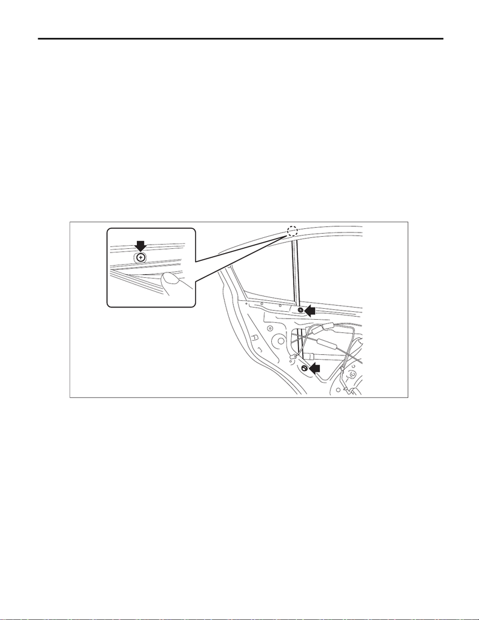

Rear Door Glass

GLASS/WINDOWS/MIRRORS

11.Rear Door Glass

A: REMOVAL

1) Disconnect the ground cable from battery. <Ref. to NT-5, BATTERY, NOTE, Note.>

NOTE:

For models other than STI model, disconnect the ground terminal from battery sensor.

2) Remove the trim panel - rear door. <Ref. to EI-57, REAR DOOR, REMOVAL, Door Trim.>

3) Remove the sealing cover - rear door. <Ref. to EB-41, REMOVAL, Rear Sealing Cover.>

4) Connect the battery ground terminal. <Ref. to NT-5, BATTERY, NOTE, Note.>

NOTE:

For models other than STI model, connect the ground terminal to battery sensor.

5) Remove the glass assembly - rear door.

(1) Install the switch - power window and then turn the ignition switch to ON.

sition.

(3) Remove the running channel - rear door.

(4) Remove the screws and bolts, and then remove the sash COMPL - rear partition.

GW-01409

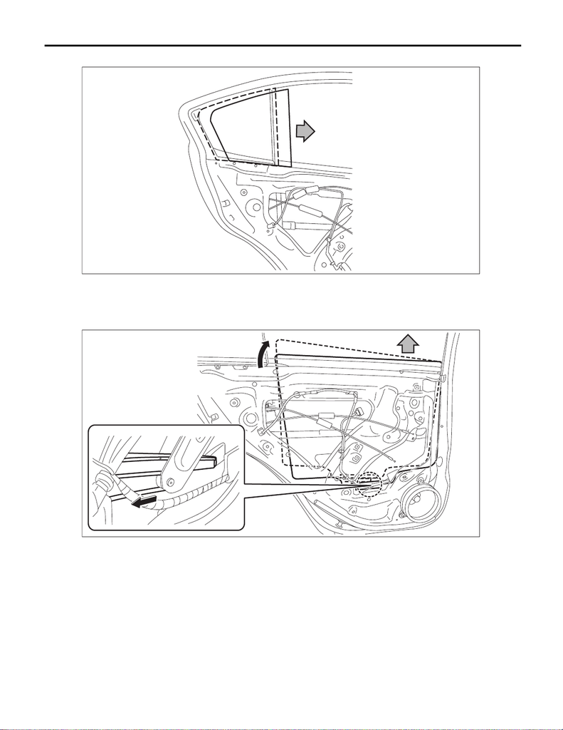

GW-35

Rear Door Glass

GLASS/WINDOWS/MIRRORS

(5) Remove the glass - rear door partition.

assembly - rear, then remove the glass assembly - rear door.

CAUTION:

Avoid impact and damage to the glass assembly - rear door.

GW-01410

GW-01043

[figure not shown]

GW-36

Rear Door Glass

GLASS/WINDOWS/MIRRORS

B: INSTALLATION

1) Install the glass assembly - rear door.

CAUTION:

Avoid impact and damage to the glass assembly - rear door.

2) Install the glass - rear door partition and the sash COMPL - rear partition.

Tightening torque:

7.5 N·m (0.8 kgf-m, 5.5 ft-lb)

3) Install the running channel - rear door.

CAUTION:

Check that the running channel - rear door is securely fixed to the panel assembly - rear door and to

the sash COMPL - rear partition.

4) Install the sealing cover - rear door. <Ref. to EB-41, INSTALLATION, Rear Sealing Cover.>

5) Install the trim panel - rear door. <Ref. to EI-58, INSTALLATION, Door Trim.>

6) Connect the battery ground terminal. <Ref. to NT-5, BATTERY, NOTE, Note.>

NOTE:

For models other than STI model, connect the ground terminal to battery sensor.